# Reproducible Research: Peer Assessment 1

Loading and preprocessing the data

```r
library(ggplot2)
library(plyr)
library(lattice)
library(knitr)
Activity <- read.csv("Activity.csv")
Activity$day <- weekdays(as.Date(activity$date))
Activity$DateTime<- as.POSIXct(activity$date, format="%Y-%m-%d")
removeNa <- Activity[!is.na(Activity$steps),]
```

What is mean total number of steps taken per day? Calculate the total number of steps taken per day

```r
meanSteps <- aggregate(Activity$steps ~ Activity$date, FUN=sum, )
colnames(meanSteps)<- c("Date", "Steps")
```

histogram

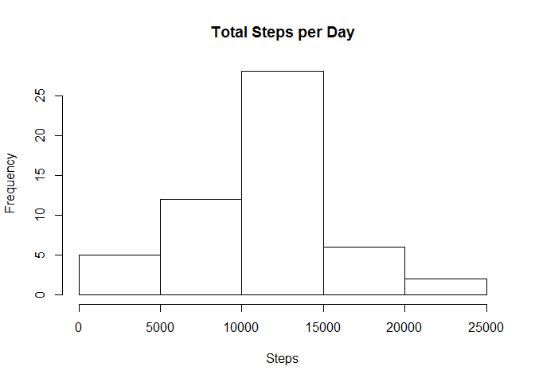

Calculate and report the mean and median of the total number of steps taken per day

```r
as.integer(mean(meanSteps$Steps))
```

```
## [1] 10766
```

```r
as.integer(median(meanSteps$Steps))
```

```
## [1] 10765
```

10766 steps-average

10765 steps-meadian.

What is the average daily activity pattern?

Make a time series plot (i.e. type = “l”) of the 5-minute interval (x-axis) and the average number of steps taken, averaged across all days (y-axis)

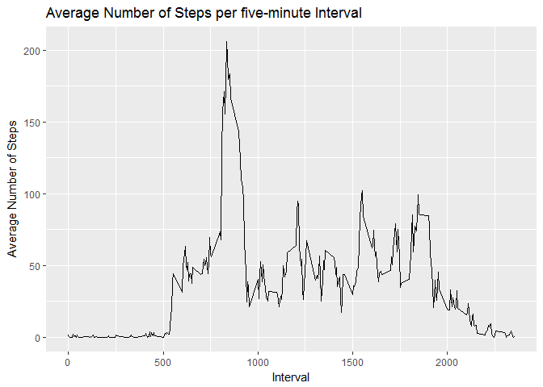

Which 5-minute interval, on average across all the days in the dataset, contains the maximum number of steps?

```r
maxSteps <- max(averageSteps$Avg)
averageSteps[averageSteps$Avg==maxSteps,1]
```

```
## [1] 835
```

Imputing missing values Calculate and report the total number of missing values in the dataset (i.e. the total number of rows with NAs)

```r
nrow(Activity[is.na(Activity$steps),])
```

```
## [1] 2304
```

2304 missing values

Devise a strategy for filling in all of the missing values in the dataset. The strategy does not need to be sophisticated.

```r
averageMeanSteps <- ddply(removeNa, .(interval, day), summarize, Avg = mean(steps))
nullData<- Activity[is.na(Activity$steps),]
fillData<-merge(nullData, averageMeanSteps, by=c("interval", "day"))
```

substituted with the average and mean steps of the five-minute interval

Create a new dataset that is equal to the original dataset but with the missing data filled in.

```r
fillData2<- fillData[,c(6,4,1,2,5)]
colnames(fillData2)<- c("steps", "date", "interval", "day", "DateTime")
merged <- rbind(removeNa, fillData2)
meanSteps2 <- aggregate(merged$steps ~ merged$date, FUN=sum, )
colnames(meanSteps2)<- c("Date", "Steps")
as.integer(mean(meanSteps2$Steps))
```

```
## [1] 10821
```

mean -10821

```r
as.integer(median(meanSteps2$Steps))
```

```
## [1] 11015
```

median - 11015

Only minor impact but does not distort the data

Make a histogram of the total number of steps taken each day and Calculate and report the mean and median total number of steps taken per day.

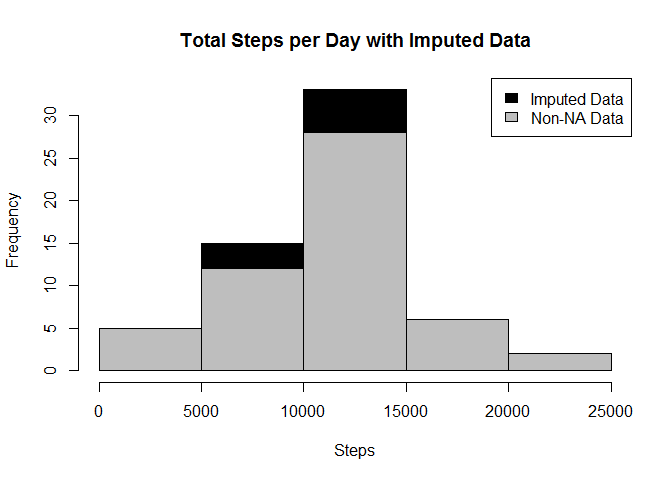

Are there differences in activity patterns between weekdays and weekends?

Create a new factor variable in the dataset with two levels - “weekday” and “weekend” indicating whether a given date is a weekday or weekend day.

```r
merged$DayCategory <- ifelse(merged$day %in% c("Saturday", "Sunday"), "Weekend", "Weekday")
```

Make a panel plot containing a time series plot (i.e. type = “l”) of the 5-minute interval (x-axis) and the average number of steps taken, averaged across all weekday days or weekend days (y-axis).

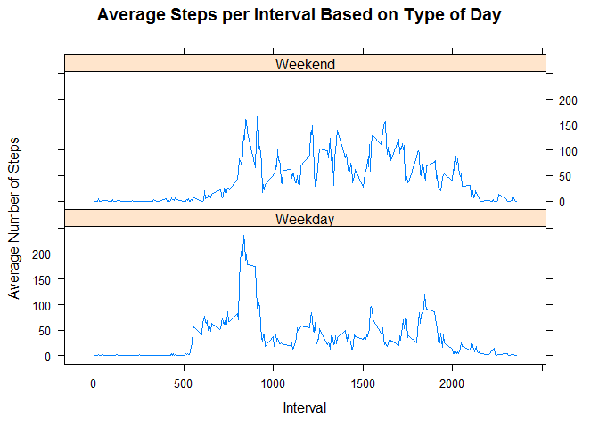